# 統計學習與深度學習作業一 B09303047林奕霆

## 第一題

```python
import pickle
from sklearn import preprocessing
import numpy as np

# Load data
with open('D:/Users/User/Desktop/msd_data1.pickle', 'rb') as fh1:
    msd_data = pickle.load(fh1)

doscaling = 1

if (doscaling == 1):
    xscaler = preprocessing.StandardScaler().fit(msd_data['X_train'])
    #standardize feature values
    X_train = xscaler.transform(msd_data['X_train'])
    X_test = xscaler.transform(msd_data['X_test'])
else:
    X_train = msd_data['X_train']
    X_test = msd_data['X_test']

Y_train = msd_data['Y_train']
Y_test = msd_data['Y_test']
```

```python
# Q1.1
class myknn_regressor():
    def __init__(self, n_neighbors = 10, mean_type = "equal_weight"):
        """mean_type can be equal_weight or remove_outliers.
                              equal_weight use the same weight for all neighbors.
                              remove_outliers remove neighbors out in [Q1 - 1.5 IQR, Q3 + 1.5IQR]."""
        self.n_neighbors= n_neighbors
        self.mean_type= mean_type

    def fit(self, x_train, y_train):
         ### Add your code here ###
        self.x_train = x_train
        self.y_train = y_train

    def predict(self, x_test):
        """use remove_outliers only if k>=10"""
         ### Add your code here ###
        if self.mean_type == "equal_weight" or self.n_neighbors < 10:
            distances = self.compute_distances(x_test)
            test_labels = self.predict_labels(distances)
            return test_labels
        if self.mean_type == "remove_outliers" and self.n_neighbors >= 10:
            distances = self.compute_distances(x_test)
            test_labels = self.predict_labels(distances)

            return test_labels
    def compute_distances(self, x_test):
        num_test = x_test.shape[0]
        num_train = self.x_train.shape[0]
        distances = np.zeros((num_test, num_train))
        for i in range(num_test):
            for j in range(num_train):
                distances[i][j] = np.sum((x_test[i]-self.x_train[j])**2)**0.5
        return distances

    def predict_labels(self, distances):
        num_test = distances.shape[0]
        y_pred = np.zeros(num_test)
        if self.mean_type == "equal_weight" or self.n_neighbors < 10:
            for i in range(num_test):
                closest_y = []
                closest_y = self.y_train[np.argsort(distances[i])[:self.n_neighbors]]
                y_pred[i] = sum(closest_y)/self.n_neighbors
            return y_pred
        if self.mean_type == "remove_outliers" and self.n_neighbors >= 10:
            for i in range(num_test):
                closest_y2 = []
                closest_y = []
                closest_y2 = self.y_train[np.argsort(distances[i])[:self.n_neighbors]]
                closest_y2 = np.sort(closest_y2)
                Q1 = np.percentile(closest_y2, 25)
                Q3 = np.percentile(closest_y2, 75)
                iqr = Q3 - Q1

                for j in range(self.n_neighbors):
                    if (closest_y2[j] <= Q3 + 1.5*iqr) and (closest_y2[j] >= Q1 - 1.5*iqr):
                        closest_y.append(closest_y2[j])
                y_pred[i] = sum(closest_y)/len(closest_y)
            return y_pred

myknn = myknn_regressor(20, "equal_weight")
myknn.fit(X_train, Y_train)
ypred = myknn.predict(X_test)
```

```python
#Q1.2
def rmse(y_pred, y_test):
    rmse_result = (np.sum((y_test-y_pred)**2)/y_pred.shape[0])**0.5
    return rmse_result
rmse = rmse(ypred, Y_test)
print(rmse)
print(ypred[:20])
```

```
10.25126451549596
[1993.35 1993.8  2000.65 1991.5  1992.8  1998.5  1988.1  1991.65 2002.25
 2003.   2000.5  1998.65 1995.55 1997.2  1995.05 1997.4  1992.15 2000.45
 2003.2  1995.75]
```

```python
#Q1.3
myknn = myknn_regressor(20, "remove_outliers")
myknn.fit(X_train, Y_train)
ypred = myknn.predict(X_test)
```

```python
def rmse(y_pred, y_test):
    rmse_result = (np.sum((y_test-y_pred)**2)/y_pred.shape[0])**0.5
    return rmse_result
rmse = rmse(ypred, Y_test)
print(rmse)
print(ypred[:20])
```

```
10.212572466080376
[1993.35       1993.8        2000.65       1992.73684211 1992.8
 2000.         1988.1        1991.65       2002.25       2003.94736842
 2000.5        2000.94444444 1995.55       1997.2        1998.61111111
 1997.4        1992.15       2003.83333333 2003.2        1995.75      ]
```

## 第二題

```python
import matplotlib.pyplot as plt
```

```
[13.911074724837043, 12.068170946750795, 11.389120864846157, 11.1123354880961, 10.894692897614565, 10.468549209697088, 10.293424167991525, 10.212572466080376, 10.19147537897133, 10.132105705172414, 10.109608004792985, 10.093231539122922, 10.080018891479627, 10.08078333324933, 10.059767600751963, 10.…
```

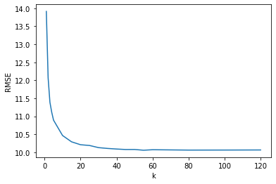

```python
# The third case(以myknn_regressor)
def rmse2(y_pred, y_test):
    rmse_result = (np.sum((y_test-y_pred)**2)/y_pred.shape[0])**0.5
    return rmse_result
k_list = [1,2,3,4,5,10,15,20,25,30,35,40,45,50,55,60,80,100,120]
rmse_list = []
for i in range(len(k_list)):
    myknn = myknn_regressor(k_list[i], "remove_outliers")
    myknn.fit(X_train, Y_train)
    ypred = myknn.predict(X_test)
    rmse1 = rmse2(ypred, Y_test)
    rmse_list.append(rmse1)
print(rmse_list)
plt.plot(k_list, rmse_list)
plt.xlabel('k')
plt.ylabel('RMSE')
```

```
[13.911074724837043, 12.068170946750795, 11.389120864846157, 11.1123354880961, 10.894692897614565, 10.425998912973919, 10.318171959828572, 10.25126451549596, 10.23762722509469, 10.215977156359507, 10.205243203546763, 10.204332770527754, 10.207243171822855, 10.206033712139762, 10.208862384446808, 10.…
```

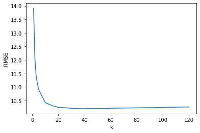

```python
# The first case
from sklearn.neighbors import KNeighborsRegressor
rmse_list1 = []
for i in k_list:
    neigh = KNeighborsRegressor(n_neighbors = i)
    neigh.fit(X_train, Y_train)
    ypred = neigh.predict(X_test)
    rmse3 = rmse2(ypred, Y_test)
    rmse_list1.append(rmse3)
print(rmse_list1)
plt.plot(k_list, rmse_list1)
plt.xlabel('k')
plt.ylabel('RMSE')
```

```
[14.923638966418345, 12.777499755429464, 12.075674967716129, 11.767805657810635, 11.466392632384432, 11.07746090040493, 10.888979137947995, 10.797788546734928, 10.79007301797969, 10.75026561256701, 10.717738719772289, 10.714437504678756, 10.698494013475852, 10.69110105960404, 10.682608734124413, 10.…
```

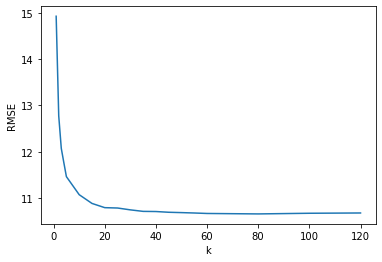

```python
# The second case
with open('D:/Users/User/Desktop/msd_data1.pickle', 'rb') as fh2:
    msd_data = pickle.load(fh2)

doscaling = 0

if (doscaling == 1):
    xscaler = preprocessing.StandardScaler().fit(msd_data['X_train'])
    #standardize feature values
    X_train = xscaler.transform(msd_data['X_train'])
    X_test = xscaler.transform(msd_data['X_test'])
else:
    X_train = msd_data['X_train']
    X_test = msd_data['X_test']

Y_train = msd_data['Y_train']
Y_test = msd_data['Y_test']

from sklearn.neighbors import KNeighborsRegressor
rmse_list2 = []
for i in k_list:
    neigh = KNeighborsRegressor(n_neighbors = i)
    neigh.fit(X_train, Y_train)
    ypred = neigh.predict(X_test)
    rmse3 = rmse2(ypred, Y_test)
    rmse_list2.append(rmse3)
print(rmse_list2)
plt.plot(k_list, rmse_list2)
plt.xlabel('k')
plt.ylabel('RMSE')
```

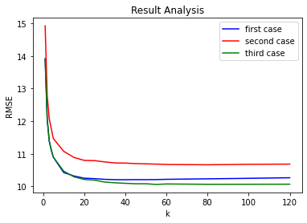

```python
plt.title('Result Analysis')
plt.plot(k_list, rmse_list1, color = 'blue', label = 'first case')
plt.plot(k_list, rmse_list2, color = 'red', label = 'second case')
plt.plot(k_list, rmse_list, color = 'green', label = 'third case')
plt.legend() # 顯示圖例

plt.xlabel('k')
plt.ylabel('RMSE')
plt.show()
```

## 第三題

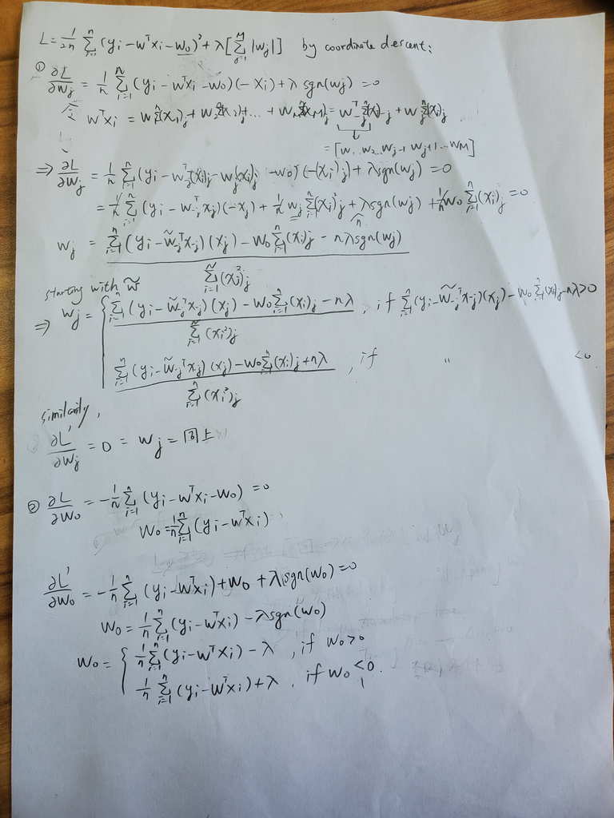

```python
#Q3.1
from IPython.display import Image
Image(filename="D:/Users/User/Desktop/20220928_135817.jpg",width=700,height=1300)
```

上方wj、w0忘了考慮在其他狀況時=0，在此補上。

```python
import pickle
from sklearn import preprocessing
import numpy as np
np.set_printoptions(suppress=True)

#Load data
with open('D:/Users/User/Desktop/msd_data1.pickle', 'rb') as fh1:
    msd_data = pickle.load(fh1)

xscaler = preprocessing.StandardScaler().fit(msd_data['X_train'])
#standardize feature values
X_train_sd = xscaler.transform(msd_data['X_train'])
X_test_sd = xscaler.transform(msd_data['X_test'])

#outcome values
Y_train = msd_data['Y_train']
Y_test = msd_data['Y_test']
```

```python
#Q3.2
import numpy as np

class mylasso():
    def __init__(self, lamcoef = 0.1, max_iter=1000, tol=1e-6, const_regu = False):
        """lamcoef: the regularization coefficient
           max_iter: maximum number of iteration for model training
           tol: tolerance for the stopping criteria for model training
           const_regu: whether the constant term should be regularized, default to False
           """
        self.lamcoef = lamcoef
        self.max_iter = max_iter
        self.tol = tol
        self.const_regu = const_regu

    def fit(self, x_train, y_train, winit = "ridge", keep_traindata = True, verbose = False):
        """Fit a Lasso model
           x_train: a numpy matrix that contains training features
           y_train: a numpy matrix that contains the label
           winit: how weights are initialized, default to "ridge", ridge regression
           keep_traindata: whether the object is going to keep training data after the training process completed
           verbose: output a lot of message"""
        #如果keep_traindata為真，那mylasso物件應該保留一份Training Data在物件的Attribute內。否則不要保留Training Data。
        if keep_traindata == True:
            self.x_train = x_train
            self.y_train = y_train
        self.m, self.n = x_train.shape #共有m列、n行
        self.w = np.zeros(self.n)
        self.winit = winit
        self.keep_traindata = keep_traindata
        self.verbose = verbose

        #蒐集常數項並將其加到x_train第一行
        col_const = np.ones((self.m, 1))
        x_intercept = np.concatenate((col_const, x_train), axis = 1)

        #求包含常數項的初始w
        w = np.dot(np.dot(np.linalg.inv(self.lamcoef*np.identity(self.n + 1) + np.dot(x_intercept.T, x_intercept)), x_intercept.T), y_train)
        self.w0 = w[0]
        self.w = w[1:]

        # 尋找使l最小的w
        last_loss = 10000000000000
        min_loss = 100000000000000
        min_loss_w = self.w
        min_loss_w0 = self.w0
        for i in range(self.max_iter):
            for j in range(self.n):
                x_noj = np.delete(x_train, j, axis = 1)
                w_noj = np.delete(self.w, j, axis = 0)
                a = y_train - np.dot(x_noj,w_noj) - self.w0
                w_jstar = np.dot(y_train - np.dot(x_noj,w_noj) - self.w0, x_train[:, j]) / np.dot(x_train[:, j],x_train[:, j])
                th = (self.m * self.lamcoef) / np.dot(x_train[:, j],x_train[:, j])

                if self.w[j] > th:
                    self.w[j] = w_jstar - th
                elif self.w[j] < -th:
                    self.w[j] = w_jstar + th
                else:
                    self.w[j] = 0
            if self.const_regu == True:
                if np.mean(y_train - np.dot(x_train, self.w)) - self.lamcoef > 0:
                    self.w0 = np.mean(y_train - np.dot(x_train, self.w)) - self.lamcoef
                elif np.mean(y_train - np.dot(x_train, self.w)) - self.lamcoef < 0:
                    self.w0 = np.mean(y_train - np.dot(x_train, self.w)) + self.lamcoef
                else:
                    self.w0 = 0
            else:
                self.w0 = np.mean(y_train - np.dot(x_train, self.w))
        #計算L
            if self.const_regu == True:
                loss = np.mean(np.square(y_train - np.dot(x_train,self.w) - self.w0))*0.5 + self.lamcoef*(abs(self.w0) + np.sum(abs(self.w)))
            else:
                loss = np.mean(np.square(y_train - np.dot(x_train,self.w) - self.w0))*0.5+ self.lamcoef*np.sum(abs(self.w))
            if loss < min_loss:
                min_loss = loss
                min_loss_w = self.w
                min_loss_w0 = self.w0
            if abs(last_loss - loss) < self.tol:
                break
            last_loss = loss

        nonzero = 0
        for i in min_loss_w:
            if i != 0:
                nonzero += 1
        # 更新最佳化後的w與w0
        self.optimize_w = min_loss_w
        self.optimize_w0 = min_loss_w0
        self.min_loss = min_loss
        self.nonzero = nonzero




    def predict(self, x_test):
        """Make prediction using trained model"""
        ypred = np.dot(x_test, self.optimize_w) + self.optimize_w0
        return ypred


    np.set_printoptions(suppress=True)
mlo =mylasso(lamcoef = 0.1)
mlo.fit(X_train_sd, Y_train)
ypred = mlo.predict(X_train_sd)
```

Q3.3 列出Training Loss、Root Mean Squared Error (RMSE) in Training Data、Mean Absolute Error (MAE) in Training Data、Intercept (截距項)、Feature Weights (除了截距項的所有權重)、非零權重的個數。為了讓結果容易閱讀，請使用np.set_printoptions(suppress=True)關閉Scientific Notation。

```python
np.set_printoptions(suppress=True)
mlo = mylasso(lamcoef = 0.1)
mlo.fit(X_train_sd, Y_train)
ypred = mlo.predict(X_train_sd)

print(f'Traing Loss: {mlo.min_loss}')
RMSE = np.sqrt(np.mean(np.square(Y_train - ypred)))
print(f'RMSE: {RMSE}')
MAE = np.mean(abs(Y_train - ypred))
print(f'MAE: {MAE}')
print(f'Intercept: {mlo.optimize_w0}')
print(f'Feature Weight: {mlo.optimize_w}')
print(f'非零權重個數: {mlo.nonzero}')
```

```
Traing Loss: 49.93883109015513
RMSE: 9.732883604254253
MAE: 6.992162552304418
Intercept: 1998.266
Feature Weight: [ 4.64090496 -2.47120161 -1.05422021  0.         -0.39539259 -2.99533729
  0.         -0.41128967 -0.43694469  0.         -0.2034431  -0.37918189
  0.59052052  0.         -0.28863628  0.5805832   0.          0.54482726
  0.41441286  1.10532099  0.47707889  0.          1.86947027  0.
 -0.13678731  0.          0.69256035  0.          0.          0.
 -0.20167951 -0.26969234  0.          0.          0.         -0.32136856
  0.          0.31520768  0.3463576   0.         -0.25617814  0.
  0.          0.          0.          0.          0.         -0.23887528
  0.          0.          0.29977652  0.          0.          0.
  0.          0.         -0.64301823  0.20630784 -0.27831127  0.
 -0.21185575  0.          0.          0.         -0.27948376  0.
  0.          0.          0.          0.         -0.17373703  0.
  0.          0.21830713  0.1294019   0.          0.         -0.56784876
  0.          0.          0.          0.          0.23496788  0.18052493
  0.43197505  0.          0.         -0.25020555  0.          0.        ]
非零權重個數: 40
```

Q3.4 使用上一小題的模型計算測試資料的預測值。列出前五筆資料的預測年分、Test RMSE、Test MAE。

```python
np.set_printoptions(suppress=True)
mlo = mylasso(lamcoef = 0.1)
mlo.fit(X_train_sd, Y_train)
ypred = mlo.predict(X_test_sd)
print(f'預測年份:{ypred[:5]}')
RMSE = np.sqrt(np.mean(np.square(Y_test - ypred)))
print(f'RMSE: {RMSE}')
MAE = np.mean(abs(Y_test - ypred))
print(f'MAE: {MAE}')
```

```
預測年份:[1992.08032826 1998.81382346 2002.42941341 1990.99421767 1994.50603525]
RMSE: 9.653163607390375
MAE: 6.925122127808742
```

Q3.5 使用下面的 λ訓練模型: 0.0001, 0.0005, 0.001, 0.005, 0.01, 0.05, 0.1, 0.5, 1, 2。記錄每一個 λ的Training Loss、Number of Nonzero Weights、Average Weight Size (Mean of Absolute Weight)、Training RMSE、Test RMSE。將所有的結果列表、畫折線圖、並寫下你對結果的觀察。

```python
training_loss = []
nonzero = []
MAW = []
training_rmse = []
test_rmse = []
np.set_printoptions(suppress=True)
lambda_list = [0.0001, 0.0005, 0.001, 0.005, 0.01, 0.05, 0.1, 0.5, 1, 2]
for i in lambda_list:
    mlo = mylasso(lamcoef = i)
    mlo.fit(X_train_sd, Y_train)
    ypred = mlo.predict(X_train_sd)
    training_loss.append(mlo.min_loss)
    nonzero.append(mlo.nonzero)
    MAW.append(np.mean(abs(mlo.optimize_w)))
    RMSE = np.sqrt(np.mean(np.square(Y_train - ypred)))
    training_rmse.append(RMSE)
    ypred = mlo.predict(X_test_sd)
    RMSE = np.sqrt(np.mean(np.square(Y_test - ypred)))
    test_rmse.append(RMSE)
import pandas as pd
dataframe = pd.DataFrame({'Training Loss':training_loss, 'Number of Non-zero Weight': nonzero,'Average Weight Size': MAW, 'Train RMSE': training_rmse, 'Test RMSE': test_rmse}, index=lambda_list)
dataframe.index = [0.0001, 0.0005, 0.001, 0.005, 0.01, 0.05, 0.1, 0.5, 1, 2]
dataframe
```

|  | Training Loss | Number of Non-zero Weight | Average Weight Size | Train RMSE | Test RMSE |
| --- | --- | --- | --- | --- | --- |
| 0.0001 | 46.570461 | 90 | 0.470606 | 9.650516 | 9.644363 |
| 0.0005 | 46.587379 | 90 | 0.469507 | 9.650518 | 9.644092 |
| 0.0010 | 46.608460 | 90 | 0.467906 | 9.650528 | 9.643539 |
| 0.0050 | 46.774657 | 87 | 0.455683 | 9.650865 | 9.640032 |
| 0.0100 | 46.976842 | 85 | 0.442829 | 9.651766 | 9.636343 |
| 0.0500 | 48.422206 | 62 | 0.358704 | 9.675547 | 9.627528 |
| 0.1000 | 49.938831 | 40 | 0.286035 | 9.732884 | 9.653164 |
| 0.5000 | 56.729694 | 5 | 0.104318 | 10.201508 | 10.113844 |
| 1.0000 | 60.226903 | 1 | 0.015377 | 10.883412 | 10.786623 |
| 2.0000 | 61.565822 | 0 | 0.000000 | 11.096470 | 10.968542 |

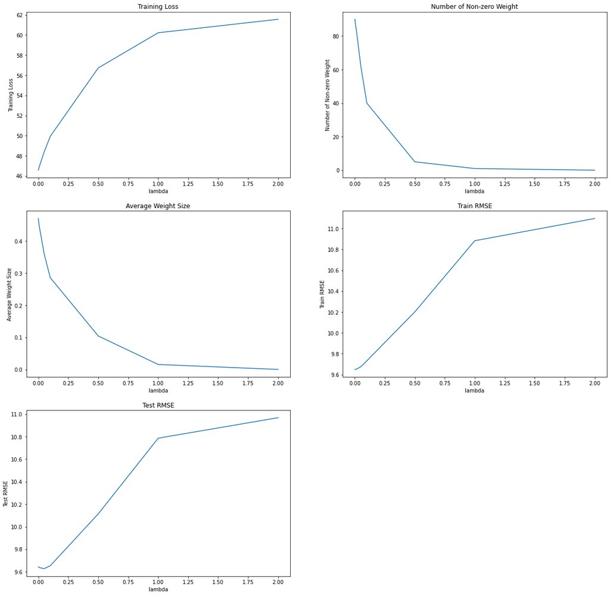

```python
data = [training_loss, nonzero, MAW, training_rmse, test_rmse]
label = ['Training Loss', 'Number of Non-zero Weight', 'Average Weight Size', 'Train RMSE', 'Test RMSE']

plt.figure(figsize = (20, 20))
for i in range(5):
    plt.subplot(3, 2, i+1)
    plt.plot(dataframe.index, data[i])
    plt.title(label[i])
    plt.xlabel('lambda')
    plt.ylabel(label[i])
```

1.training loss, RMSE, 與lambda呈正相關，當Lambda增加，可能會讓模型更不精準

2.Non-zero Weight, Average Weight Size 與lambda呈負相關

3.Train RMSE 與 Test RMSE 相當